# act_report

## Report: Act Report

This report is a short analysis of three datasets gathered with the TwitterAPI. The site WeRateDogs from user @dog_rates has 9 million followers (as of September 2021) and an own webpage weratedogs.com.

I have created multiple visualizations to address the questions I had.

**On what days of the week, people are engaged on twitter?**

This first question struck me to search for a direct relationship with the days of the week and the tweet counts.

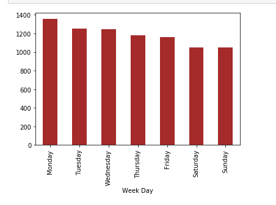

As it can be seen from the above bar chart, people tend to send less tweets on the weekend. Monday happens to be the day for the most tweets tweeted.

The second question that I wanted dig was **What breeds are most favored by the people?** In order for me to be able to find the answer to this question, I have used the 'p1_y' column as my main entry point to my analyses. One issue with the column is that it represents the first guess of the image recognition tool. Meaning that there is not 100% guarantee the image represents an actual dog. This is noted.

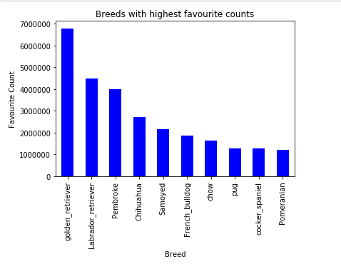

As it can be seen from the above chart, Golden Retriever is the most popular breed amongst the top 10 most favourited breeds.

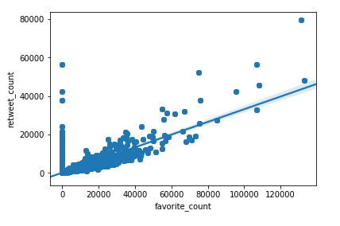

On the last data visualization, I wanted to answer **if there is a positive correlation between the favourited and retweeted tweets**. This may not be a strong argument to discuss but the underlying goal of this question is to answer whether retweets get the favourited or not. By doing so I have used seaborn's regplot() function. It seems there is a strong positive relationship between the two.

Finally, more conclusions can be derived from this study but these are some of them answered by me in this project.